# NLP Project: ML Algorithms on Text Data

## Each student must extract tweets from twitter. Perform pre-processing and text representation. Apply ML algorithms for classification/clustering. 1. Creating Datasets a. Extract 5000 tweets with any 5 search labels of your choice. (1000 each). Eg(#cricket, #football, #basketball, #tennis, #hockey). b. Create one dataset for all the tweets extracted along with labels as second column. Shuffle the dataset. 2. Pre-processing a. Clean the data by removing tags, user handles, numbers, and other characters. b. Stem tokens for basic vectorization c. Lemma tokens for embeddings 3. Text representation a. Vectorise each document in the dataset with tf-idf vectorization with n-grams (use stemmed data). b. Create document embeddings by summation of word vectors taken from any two pre-trained models. The tokens must be lemmas. 4. Apply machine learning techniques (any two algorithms) for classification/clustering on a. 3.a data b. 3.b data 5. Evaluate the results (4.a and 4.b) which outperforms. a. For clustering compare at least 10 records’ label with the clusters created. b. Present a chart as for classification:

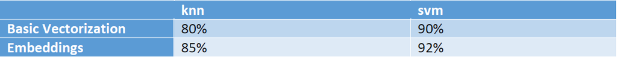

```python
import twitter_info

import tweepy
from imdb import IMDb

import time
import json
import pandas as pd
import numpy as np
from datetime import datetime
import os
import re
import glob
from tqdm import tqdm

from nltk.tokenize import word_tokenize
import nltk
from nltk import pos_tag
from nltk.corpus import stopwords
from nltk.stem import WordNetLemmatizer
lm = WordNetLemmatizer()
from nltk.stem.porter import PorterStemmer
pm = PorterStemmer()

from sklearn.feature_extraction.text import TfidfVectorizer
from sklearn.svm import SVC
from sklearn.naive_bayes import MultinomialNB
from sklearn.neighbors import KNeighborsClassifier
from sklearn.decomposition import TruncatedSVD
from sklearn.model_selection import GridSearchCV
from sklearn.ensemble import RandomForestClassifier
import xgboost as xgb
#from sklearnex import patch_sklearn
#patch_sklearn()

import codecs
from glove import Corpus, Glove
from gensim.scripts.glove2word2vec import glove2word2vec
from gensim.models import Word2Vec
from gensim.models import KeyedVectors
from gensim.models import FastText
from tensorflow.keras.preprocessing.text import Tokenizer
from tensorflow.keras.preprocessing.sequence import pad_sequences
from keras.preprocessing import text, sequence
from keras import layers, models, optimizers

from sklearn.model_selection import train_test_split
from sklearn.model_selection import cross_val_score
from sklearn.metrics import ConfusionMatrixDisplay, confusion_matrix
from sklearn.metrics import plot_confusion_matrix
from sklearn.metrics import accuracy_score
from sklearn.metrics import classification_report

from pprint import pprint
import matplotlib.pyplot as plt
import seaborn as sn

from pickle import dump
from pickle import load
```

```python
%run helper_functions.ipynb
```

```python
consumer_key = twitter_info.API_Key
consumer_secret = twitter_info.API_Key_Secret
access_token = twitter_info.Access_Token
access_token_secret = twitter_info.Access_Token_Secret
bearer_token = twitter_info.Bearer_Token
```

```python
client = tweepy.Client(bearer_token = bearer_token)
auth = tweepy.OAuthHandler(consumer_key, consumer_secret)
auth.set_access_token(access_token, access_token_secret)
API = tweepy.API(auth, wait_on_rate_limit=True, retry_count=5, retry_delay=180)
```

```python
s = str(datetime.now())
s = s[:16].replace(" ", "_").replace(":","")
```

```python
class_list = ['Star Wars','Marvel Cinematic Universe','MonsterVerse','Wizarding World','DC Extended Universe']
class_query_list = []
class_file_name = ['input/star_wars_keywords.txt', 'input/Marvel_Cinematic_Universe_MCU_keywords.txt',
                   'input/MonsterVerse_keywords.txt', 'input/Wizarding_World_keywords.txt', 'input/DC_Extended_Universe_keywords.txt']
class_keyword_list = []
for i in range(len(class_list)):
    with open(class_file_name[i]) as f:
        class_keyword_list.append(f.readlines())
    class_keyword_list[i] = [key_word.strip() + ' OR ' for key_word in class_keyword_list[i]]
    class_temp = ''.join(class_keyword_list[i])
    class_query_list.append(class_temp[:-4])
```

```python
for i in range(len(class_list)):
    print("\n", class_query_list[i], class_list[i], len(class_query_list[i]), "\n")
```

```
 "Star Wars" OR "Darth Vader" OR "Obi-Wan Kenobi" OR "Yoda" OR "Princess Leia" OR "R2-D2" OR "Chewbacca" OR "Darth Maul" OR "C-3PO" OR "Q ira" OR "Uncle Owen" OR "Admiral Ackbar" OR "Jabba Hut" OR "Skywalker" OR "A New Hope" OR "Empire Strikes Back" OR "Return Jedi" OR "Phantom Menace" OR "Attack Cl…


 "Marvel Cinematic Universe" OR "MCU" OR "Thor" OR "Ant Man" OR "Falcon" OR "Hulk" OR "Luke Cage" OR "Doctor Strange" OR "Groot" OR "Punisher" OR "Black Widow" OR "Jessica Jones" OR "Dare devil" OR "Captain America" OR "Loki" OR "Black Panther" OR "Spider Man" OR "Iron Man" OR "Scarlet Witch" OR "Ca…


 "MonsterVerse" OR "King Kong" OR "Anguirus" OR "Godzilla" OR "MechaKing Ghidorah" OR "Mechagodzilla" OR "King Ghidorah" OR "MUTO" OR "Monster X" OR "Mothra" OR "Preston Packard" OR "Alan Jonah" OR "Emma Russell" OR "Mark Russell" OR "James Conrad" OR "Mason Weaver" OR "Ford Brody" OR "Madison Russe…


 "Wizarding World" OR "Molly Weasley" OR "Newt Scamander" OR "Draco Malfoy" OR "Sirius Black" OR "Voldemort" OR "Dumbledore" OR "Severus Snape" OR "Ron Weasley" OR "Hermione Granger" OR "Harry Potter" OR "Philosopher's Stone" OR "Chamber Secrets" OR "Prisoner Azkaban" OR "Goblet Fire" OR "Order the …


 "DC Extended Universe" OR "DCEU" OR "Flash" OR "Superman" OR "Batman" OR "Wonder Woman" OR "Aquaman" OR "Cyborg" OR "Shazam" OR "Harley Quinn" OR "Deadshot" OR "Bloodsport" OR "Peacemaker" OR "Zod" OR "Faora-Ul" OR "Lex Luthor" OR "Joker" OR "Man of Steel" OR "Dawn of Justice" OR "Suicide Squad" OR…
```

```python
%%time
for i in range(len(class_list)):
    print("\n", class_query_list[i], class_list[i], "\n")
    extract_tweets(class_query_list[i], class_list[i], fresh_load = False)
```

```
 "Star Wars" OR "Darth Vader" OR "Obi-Wan Kenobi" OR "Yoda" OR "Princess Leia" OR "R2-D2" OR "Chewbacca" OR "Darth Maul" OR "C-3PO" OR "Q ira" OR "Uncle Owen" OR "Admiral Ackbar" OR "Jabba Hut" OR "Skywalker" OR "A New Hope" OR "Empire Strikes Back" OR "Return Jedi" OR "Phantom Menace" OR "Attack Cl…

Tweets extracted in output/tweets/ folder

 "Marvel Cinematic Universe" OR "MCU" OR "Thor" OR "Ant Man" OR "Falcon" OR "Hulk" OR "Luke Cage" OR "Doctor Strange" OR "Groot" OR "Punisher" OR "Black Widow" OR "Jessica Jones" OR "Dare devil" OR "Captain America" OR "Loki" OR "Black Panther" OR "Spider Man" OR "Iron Man" OR "Scarlet Witch" OR "Ca…

Tweets extracted in output/tweets/ folder

 "MonsterVerse" OR "King Kong" OR "Anguirus" OR "Godzilla" OR "MechaKing Ghidorah" OR "Mechagodzilla" OR "King Ghidorah" OR "MUTO" OR "Monster X" OR "Mothra" OR "Preston Packard" OR "Alan Jonah" OR "Emma Russell" OR "Mark Russell" OR "James Conrad" OR "Mason Weaver" OR "Ford Brody" OR "Madison Russe…

Tweets extracted in output/tweets/ folder

 "Wizarding World" OR "Molly Weasley" OR "Newt Scamander" OR "Draco Malfoy" OR "Sirius Black" OR "Voldemort" OR "Dumbledore" OR "Severus Snape" OR "Ron Weasley" OR "Hermione Granger" OR "Harry Potter" OR "Philosopher's Stone" OR "Chamber Secrets" OR "Prisoner Azkaban" OR "Goblet Fire" OR "Order the …

Tweets extracted in output/tweets/ folder

 "DC Extended Universe" OR "DCEU" OR "Flash" OR "Superman" OR "Batman" OR "Wonder Woman" OR "Aquaman" OR "Cyborg" OR "Shazam" OR "Harley Quinn" OR "Deadshot" OR "Bloodsport" OR "Peacemaker" OR "Zod" OR "Faora-Ul" OR "Lex Luthor" OR "Joker" OR "Man of Steel" OR "Dawn of Justice" OR "Suicide Squad" OR…

Tweets extracted in output/tweets/ folder
Wall time: 1 ms
```

```python
df_all_tweet_list = []
class_output_files = []
list_output_files = [os.getcwd()+"\\output\\tweets\\"+f for f in os.listdir("output/tweets/")]
def find_label(file_name):
    for c in class_list:
        if(file_name.find(c) >= 0):
            return c
    return None
for f in list_output_files:
    class_output_files.append([find_label(f), f])
class_output_files
```

```
[['DC Extended Universe',
  'C:\\spark\\MCA\\Semester1\\E3_NLP\\Case_Study\\output\\tweets\\nlp_tweet_DC Extended Universe_2022-04-05_0332.csv'],
 ['Marvel Cinematic Universe',
  'C:\\spark\\MCA\\Semester1\\E3_NLP\\Case_Study\\output\\tweets\\nlp_tweet_Marvel Cinematic Universe_2022-04-05_0332.csv'],
 ['MonsterVerse',
  'C:\\spark\\MCA\\Semester1\\E3_NLP\\Case_Study\\output\\tweets\\nlp_tweet_MonsterVerse_2022-04-05_0332.csv'],
 ['Star Wars',
  'C:\\spark\\MCA\\Semester1\\E3_NLP\\Case_Study\\output\\tweets\\nlp_tweet_Star Wars_2022-04-05_0332.csv'],
 ['Wizarding World',
  'C:\\spark\\MCA\\Semester1\\E3_NLP\\Case_Study\\output\\tweets\\nlp_tweet_Wizarding World_2022-04-05_0332.csv']]
```

```python
def get_full_text(label, file_name):
    df_temp = pd.read_csv(file_name)
    df_temp['label'] = label
    return df_temp[['full_text','label']]
class_tweet_list = []
for val in class_output_files:
    df_tweet_label = get_full_text(val[0], val[1])
    class_tweet_list.append(df_tweet_label)
```

```python
final_tweet_df = pd.concat(class_tweet_list, axis=0, ignore_index=True)
final_tweet_df.to_csv("output/final_output/full_tweet_list.csv", index = False)
final_tweet_df
```

|  | full_text | label |
| --- | --- | --- |
| 0 | Barnes &amp; Noble Pickup\n\nBarnes and Noble ... | DC Extended Universe |
| 1 | The True Crime Podcasts in the Batman universe... | DC Extended Universe |
| 2 | Want a free December's Dream Set!?❄🎀\nFollow m... | DC Extended Universe |
| 3 | I'm about to put some of my original artwork u... | DC Extended Universe |
| 4 | @Darmson2 @ALMUBAR04 @MUFC_Boogie @king_polams... | DC Extended Universe |
| ... | ... | ... |
| 49795 | @essteeem Harry Potter movie series | Wizarding World |
| 49796 | my heart aches reminiscing ot/12 era (minus vo... | Wizarding World |
| 49797 | @bfsnailea Harry Potter | Wizarding World |
| 49798 | Next. #Hogwartle 92 3/6\n\n⬜⬜⬜⬜⬜\n🟩🟩⬜⬜⬜\n🟩🟩🟩🟩🟩... | Wizarding World |
| 49799 | 1927 HISTORY OF THE DISEASE \n5 DAYS AGO \nFAM... | Wizarding World |

49800 rows × 2 columns

```python
df_movies_id = pd.read_csv("input/imdb_movie_list.csv")
df_movies_id
```

|  | Universe | Movie_Name | IMDB_Movie_Id | Movie_Name_Key |
| --- | --- | --- | --- | --- |
| 0 | Star Wars | A New Hope | 76759 | star_wars_a_new_hope |
| 1 | Star Wars | The Empire Strikes Back | 80684 | star_wars_the_empire_strikes_back |
| 2 | Star Wars | Return of the Jedi | 86190 | star_wars_episode_vi_return_of_the_jedi |
| 3 | Star Wars | The Phantom Menace | 120915 | star_wars_episode_i_the_phantom_menace |
| 4 | Star Wars | Attack of the Clones | 121765 | star_wars_episode_ii_attack_of_the_clones |
| ... | ... | ... | ... | ... |
| 59 | Wizarding World | Harry Potter and the Half-Blood Prince | 417741 | harry_potter_and_the_half_blood_prince |
| 60 | Wizarding World | Harry Potter and the Deathly Hallows – Part 1 | 926084 | harry_potter_and_the_deathly_hallows_part_1 |
| 61 | Wizarding World | Harry Potter and the Deathly Hallows – Part 2 | 1201607 | harry_potter_and_the_deathly_hallows_part_2 |
| 62 | Wizarding World | Fantastic Beasts and Where to Find Them | 3183660 | fantastic_beasts_and_where_to_find_them |
| 63 | Wizarding World | Fantastic Beasts: The Crimes of Grindelwald | 4123430 | fantastic_beasts_the_crimes_of_grindelwald |

64 rows × 4 columns

```python
fresh_load=False
extract_imdb_reviews(df_movies_id, fresh_load)
```

```
Extracted IMDB reviews to output/final_output/full_imdb_review_list.csv
```

```python
final_imdb_df = pd.read_csv("output/final_output/full_imdb_review_list.csv")
final_imdb_df.head()
```

|  | full_text | label |
| --- | --- | --- |
| 0 | Henry Cavil is my Superman. He's the best Supe... | DC Extended Universe |
| 1 | A QUICK " DVD-REVIEW " .HENRY CAVILL ⭐ CARRIES... | DC Extended Universe |
| 2 | Hands down the best Superman movie out there. ... | DC Extended Universe |
| 3 | At first I was very nervous at the prospect of... | DC Extended Universe |
| 4 | So we are looking at essentially a remake of S... | DC Extended Universe |

```python
final_input_df = pd.concat([final_imdb_df,final_tweet_df], axis=0, ignore_index=True)
final_input_df = final_input_df.sample(frac=1, random_state=42).reset_index(drop=True)    ## Shuffling Dataframe
final_input_df.to_csv("output/final_output/final_input_df.csv", index = False)
```

```python
final_input_df = pd.read_csv("output/final_output/final_input_df.csv")
final_input_df
```

|  | full_text | label |
| --- | --- | --- |
| 0 | ‘#GuardiansoftheGalaxy 3’ Star #KarenGillan Sa... | Marvel Cinematic Universe |
| 1 | My friend recommend me a few shows and I have ... | DC Extended Universe |
| 2 | @Papa__Drago Godzilla would win easily but jus... | MonsterVerse |
| 3 | Batman &amp; Robin...It's so camp https://t.co... | DC Extended Universe |
| 4 | why is huge ant man moving so slow | Marvel Cinematic Universe |
| ... | ... | ... |
| 51457 | @tortoisethatwon @aightmoe @Sarcasm_bender End... | DC Extended Universe |
| 51458 | @iHrtProngs SIRIUS BLACK DOES NOT HAVE A BAD H... | Wizarding World |
| 51459 | @aNorthernGarden @fiona_skywalker Agreed. She ... | Star Wars |
| 51460 | And so my long Marvel-watching journey comes t... | Marvel Cinematic Universe |
| 51461 | @mumbichilopa_jr Contact @DzaddyX for more in... | Marvel Cinematic Universe |

51462 rows × 2 columns

```python
tags = nltk.data.load('help/tagsets/upenn_tagset.pickle')
#nltk.help.upenn_tagset()
selected_tags = ['NN','NNP','NNPS','NNS','JJ','JJR','JJS']
```

```python
sample_text = final_input_df['full_text'][2]
print(pos_tag(word_tokenize(sample_text)))
print(sample_text)
sample_text = preprocess_doc(sample_text, False, True, True, selected_tags)
print(sample_text)
```

```
[('@', 'NN'), ('Papa__Drago', 'NNP'), ('Godzilla', 'NNP'), ('would', 'MD'), ('win', 'VB'), ('easily', 'RB'), ('but', 'CC'), ('just', 'RB'), ('seeing', 'VBG'), ('him', 'PRP'), ('tear', 'VB'), ('through', 'IN'), ('hundreds', 'NNS'), ('of', 'IN'), ('titans', 'NNS'), ('WOULD', 'NNP'), ('BE', 'NNP'), ('S…
@Papa__Drago Godzilla would win easily but just seeing him tear through hundreds of titans WOULD BE SO FREAKING COOL! OMG
['papa', 'drago', 'godzilla', 'tear', 'hundred', 'titan', 'cool', 'omg']
```

```python
fresh_load = False
extract_stems_lemma(selected_tags, final_input_df, fresh_load)
```

```
Stems and Lemma extracted to output/final_output/final_input_cleaned_stem_lemma.csv
```

```python
final_input_df = pd.read_csv("output/final_output/final_input_cleaned_stem_lemma.csv")
```

```python
final_input_df['label_id'] = final_input_df['label'].astype("category").cat.codes
final_input_df
```

|  | full_text | label | stem_cleaned_tokens | lemma_cleaned_tokens | label_id |
| --- | --- | --- | --- | --- | --- |
| 0 | ‘#GuardiansoftheGalaxy 3’ Star #KarenGillan Sa... | Marvel Cinematic Universe | ['guardiansofthegalaxi', 'star', 'karengillan'... | ['guardiansofthegalaxy', 'star', 'karengillan'... | 1 |
| 1 | My friend recommend me a few shows and I have ... | DC Extended Universe | ['friend', 'show', 'idea', 'flash', 'guy', 'id... | ['friend', 'show', 'idea', 'flash', 'guy', 'id... | 0 |
| 2 | @Papa__Drago Godzilla would win easily but jus... | MonsterVerse | ['papa', 'drago', 'godzilla', 'easili', 'tear'... | ['papa', 'drago', 'godzilla', 'tear', 'hundred... | 2 |
| 3 | Batman &amp; Robin...It's so camp https://t.co... | DC Extended Universe | ['batman', 'robin', 'camp'] | ['batman', 'robin', 'camp'] | 0 |
| 4 | why is huge ant man moving so slow | Marvel Cinematic Universe | ['huge', 'ant', 'man', 'move'] | ['huge', 'ant', 'man', 'slow'] | 1 |
| ... | ... | ... | ... | ... | ... |
| 51457 | @tortoisethatwon @aightmoe @Sarcasm_bender End... | DC Extended Universe | ['tortoisethatwon', 'aightmo', 'sarcasm', 'ben... | ['tortoisethatwon', 'aightmoe', 'sarcasm', 'be... | 0 |
| 51458 | @iHrtProngs SIRIUS BLACK DOES NOT HAVE A BAD H... | Wizarding World | ['ihrtprong', 'siriu', 'black', 'bad', 'hair',... | ['ihrtprongs', 'black', 'bad', 'hair', 'day'] | 4 |
| 51459 | @aNorthernGarden @fiona_skywalker Agreed. She ... | Star Wars | ['anortherngarden', 'fiona', 'skywalk', 'liter... | ['anortherngarden', 'fiona', 'skywalker', 'inp... | 3 |
| 51460 | And so my long Marvel-watching journey comes t... | Marvel Cinematic Universe | ['long', 'marvel', 'watch', 'journey', 'come',... | ['marvel', 'journey', 'come', 'end', 'endless'... | 1 |
| 51461 | @mumbichilopa_jr Contact @DzaddyX for more in... | Marvel Cinematic Universe | ['mumbichilopa', 'jr', 'contact', 'dzaddyx', '... | ['mumbichilopa', 'jr', 'contact', 'dzaddyx', '... | 1 |

51462 rows × 5 columns

```python
df_vectorization = final_input_df[['stem_cleaned_tokens', 'label', 'label_id']]
df_vectorization.head()
```

|  | stem_cleaned_tokens | label | label_id |
| --- | --- | --- | --- |
| 0 | ['guardiansofthegalaxi', 'star', 'karengillan'... | Marvel Cinematic Universe | 1 |
| 1 | ['friend', 'show', 'idea', 'flash', 'guy', 'id... | DC Extended Universe | 0 |
| 2 | ['papa', 'drago', 'godzilla', 'easili', 'tear'... | MonsterVerse | 2 |
| 3 | ['batman', 'robin', 'camp'] | DC Extended Universe | 0 |
| 4 | ['huge', 'ant', 'man', 'move'] | Marvel Cinematic Universe | 1 |

```python
dfvg = df_vectorization.groupby(['label', 'label_id'])
classes = {}
for d in dfvg:
    classes[d[0][1]] = d[0][0]
print(classes)
```

```
{0: 'DC Extended Universe', 1: 'Marvel Cinematic Universe', 2: 'MonsterVerse', 3: 'Star Wars', 4: 'Wizarding World'}
```

```python
df_embedding = final_input_df[['lemma_cleaned_tokens', 'label', 'label_id']]
df_embedding.head()
```

|  | lemma_cleaned_tokens | label | label_id |
| --- | --- | --- | --- |
| 0 | ['guardiansofthegalaxy', 'star', 'karengillan'... | Marvel Cinematic Universe | 1 |
| 1 | ['friend', 'show', 'idea', 'flash', 'guy', 'id... | DC Extended Universe | 0 |
| 2 | ['papa', 'drago', 'godzilla', 'tear', 'hundred... | MonsterVerse | 2 |
| 3 | ['batman', 'robin', 'camp'] | DC Extended Universe | 0 |
| 4 | ['huge', 'ant', 'man', 'slow'] | Marvel Cinematic Universe | 1 |

```python
len(df_embedding)
```

```
51462
```

```python
%%time
list_stemmed_data = []
list_embedding_data = []
for i in df_vectorization.index:
    exec("lst = " + df_vectorization['stem_cleaned_tokens'][i])
    lst = clean_tokens(lst)
    list_stemmed_data.append(" ".join(lst))
    exec("lst2 = " + df_embedding['lemma_cleaned_tokens'][i])
    lst2 = clean_tokens(lst2)
    list_embedding_data.append(lst2)
```

```
Wall time: 8.53 s
```

# Basic Vectorization

```python
%%time
tf_idf_vectorizer = TfidfVectorizer(ngram_range = (1,3), analyzer='word', min_df=2)
vectorized_text=tf_idf_vectorizer.fit_transform(list_stemmed_data)
```

```
Wall time: 3.29 s
```

```python
tf_idf_vectors = tf_idf_vectorizer.get_feature_names_out()
tf_idf_vectors
```

```
array(['abaddon', 'abaga', 'abaga eniolamaf', ..., 'zxshadowacexz',
       'zynthpriv', 'zypisfi'], dtype=object)
```

```python
len(tf_idf_vectors)
```

```
113472
```

```python
dump(tf_idf_vectorizer,open('models/tfidf_stem_vector.pkl', 'wb'))
```

```python
tf_idf_vectorizer = load(open('models/tfidf_stem_vector.pkl', 'rb'))
```

```python
%%time
X_sv=vectorized_text
y_sv=list(df_vectorization['label_id'])
print(X_sv.shape)
print(len(y_sv))
X_train_sv, X_test_sv, y_train_sv, y_test_sv = train_test_split(X_sv, y_sv, test_size = 0.3, shuffle = True, stratify = y_sv, random_state = 3)
```

```
(51462, 113472)
51462
Wall time: 58 ms
```

# TFIDF Multinomial Naive Bayes model

```
------------------------------------------------------------------------------------------------------------------------
Train Accuracy Score of TFIDF Multinomial Naive Bayes model created using stemmed tf_idf vector is:
 0.9740721205896233
------------------------------------------------------------------------------------------------------------------------
Test Accuracy Score of TFIDF Multinomial Naive Bayes model created using stemmed tf_idf vector is:
 0.9409288166332016
------------------------------------------------------------------------------------------------------------------------
Confusion Matrix:
[[2816  159   22   29   30]
 [ 108 2989   23   61   30]
 [  48   94 2837   29   23]
 [  38   79   17 2895   34]
 [  19   36    9   24 2990]]
```

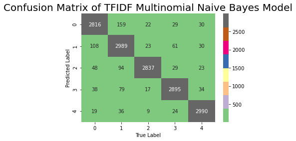

```
{0: 'DC Extended Universe', 1: 'Marvel Cinematic Universe', 2: 'MonsterVerse', 3: 'Star Wars', 4: 'Wizarding World'}
------------------------------------------------------------------------------------------------------------------------
('              precision    recall  f1-score   support\n'
 '\n'
 '           0       0.93      0.92      0.93      3056\n'
 '           1       0.89      0.93      0.91      3211\n'
 '           2       0.98      0.94      0.96      3031\n'
 '           3       0.95      0.95      0.95      3063\n'
 '           4       0.96      0.97      0.97      3078\n'
 '\n'
 '    accuracy                           0.94     15439\n'
 '   macro avg       0.94      0.94      0.94     15439\n'
 'weighted avg       0.94      0.94      0.94     15439\n')
Wall time: 436 ms
```

```python
%%time
tfidf_mnb_model = MultinomialNB()
tfidf_mnb_model, score_tfidf_mnb = evaluate_model(X_train_sv, y_train_sv, X_test_sv, y_test_sv, classes,
                                         tfidf_mnb_model, "TFIDF Multinomial Naive Bayes", "tfidf_mnb_model.pkl", fresh_load=True)
```

```python
get_cross_val(tfidf_mnb_model, X_train_sv, y_train_sv, X_test_sv, y_test_sv)
```

```
Cross validation over 10 folds:  0.9396495039376619
```

```
array([2, 2, 0, ..., 2, 0, 0])
```

```python
tf_idf_vectorizer = load(open('models/tfidf_stem_vector.pkl', 'rb'))
tfidf_mnb_model = load(open('models/tfidf_mnb_model.pkl', 'rb'))
```

```python
output_file_name = "input/rottentomatoes_reviews_final.csv"
df_rottentomatoes_reviews = pd.read_csv(output_file_name)
```

```python
df_rottentomatoes_reviews[["review", "label_name"]]
```

|  | review | label_name |
| --- | --- | --- |
| 0 | 2019's Godzilla: King of the Monsters, does pr... | MonsterVerse |
| 1 | Shazam!, it's wonderful. It's a very well-dire... | DC Extended Universe |
| 2 | The crimes of Grindelwald is a very good film ... | Wizarding World |
| 3 | An entertaining film with a great villain and ... | Marvel Cinematic Universe |
| 4 | Captain America: Civil War goes a darker direc... | Marvel Cinematic Universe |
| ... | ... | ... |
| 260 | Shazam is fun and entertaining! It succeeds in... | DC Extended Universe |
| 261 | Godzilla: King of the Monsters was the first M... | MonsterVerse |
| 262 | Not quite top tier MCU, but very close. This i... | Marvel Cinematic Universe |
| 263 | There are a lot of mixed feeling about this mo... | Marvel Cinematic Universe |
| 264 | Skull Island is more Donkey Kong than King Kon... | MonsterVerse |

265 rows × 2 columns

```python
%%time
tags = ['NN','NNP','NNPS','NNS','JJ','JJR','JJS']
classes = {0: 'DC Extended Universe', 1: 'Marvel Cinematic Universe', 2: 'MonsterVerse', 3: 'Star Wars', 4: 'Wizarding World'}
valid_tfidf_vec_list = []
for i in df_rottentomatoes_reviews.index:
    validation_text = df_rottentomatoes_reviews["review"][i]
    validation_text = preprocess_doc(validation_text, stem = True, lemma = False, stop_wrds = True, selected_tags = tags)
    vec = tf_idf_vectorizer.transform(validation_text)
    valid_tfidf_vec_list.append(vec)
```

```
Wall time: 11.3 s
```

```python
%%time
val_acc_scr_tfidf_mnb, df_rottentomatoes_reviews = validate_model(tfidf_mnb_model, "TFIDF Multinomial Naive Bayes", "tfidf_MNB", df_rottentomatoes_reviews, valid_tfidf_vec_list)
```

```
Validation Accuracy Score of TFIDF Multinomial Naive Bayes Model created using stemmed tf_idf vector is:
 0.7849056603773585
Wall time: 664 ms
```

```python
df_rottentomatoes_reviews.to_csv("output/final_output/df_rottentomatoes_reviews_predicted"+s+".csv", index = False)
df_rottentomatoes_reviews
```

|  | review | movie_name | label_name | predicted_label_MNB | y_true | y_pred_MNB | predicted_label_tfidf_rfc | y_pred_tfidf_rfc | predicted_label_tfidf_MNB | y_pred_tfidf_MNB |
| --- | --- | --- | --- | --- | --- | --- | --- | --- | --- | --- |
| 0 | 2019's Godzilla: King of the Monsters, does pr... | godzilla_king_of_the_monsters_2019 | MonsterVerse | MonsterVerse | 2 | 2 | MonsterVerse | 2 | MonsterVerse | 2 |
| 1 | Shazam!, it's wonderful. It's a very well-dire... | shazam | DC Extended Universe | DC Extended Universe | 0 | 0 | DC Extended Universe | 0 | DC Extended Universe | 0 |
| 2 | The crimes of Grindelwald is a very good film ... | fantastic_beasts_the_crimes_of_grindelwald | Wizarding World | Wizarding World | 4 | 4 | MonsterVerse | 2 | Wizarding World | 4 |
| 3 | An entertaining film with a great villain and ... | spider_man_homecoming | Marvel Cinematic Universe | Marvel Cinematic Universe | 1 | 1 | Marvel Cinematic Universe | 1 | Marvel Cinematic Universe | 1 |
| 4 | Captain America: Civil War goes a darker direc... | captain_america_civil_war | Marvel Cinematic Universe | Marvel Cinematic Universe | 1 | 1 | Marvel Cinematic Universe | 1 | Marvel Cinematic Universe | 1 |
| ... | ... | ... | ... | ... | ... | ... | ... | ... | ... | ... |
| 260 | Shazam is fun and entertaining! It succeeds in... | shazam | DC Extended Universe | DC Extended Universe | 0 | 0 | DC Extended Universe | 0 | DC Extended Universe | 0 |
| 261 | Godzilla: King of the Monsters was the first M... | godzilla_king_of_the_monsters_2019 | MonsterVerse | MonsterVerse | 2 | 2 | MonsterVerse | 2 | MonsterVerse | 2 |
| 262 | Not quite top tier MCU, but very close. This i... | avengers_infinity_war | Marvel Cinematic Universe | Marvel Cinematic Universe | 1 | 1 | DC Extended Universe | 0 | Marvel Cinematic Universe | 1 |
| 263 | There are a lot of mixed feeling about this mo... | thor_the_dark_world | Marvel Cinematic Universe | Marvel Cinematic Universe | 1 | 1 | DC Extended Universe | 0 | Marvel Cinematic Universe | 1 |
| 264 | Skull Island is more Donkey Kong than King Kon... | kong_skull_island | MonsterVerse | MonsterVerse | 2 | 2 | Marvel Cinematic Universe | 1 | MonsterVerse | 2 |

265 rows × 10 columns

# TFIDF Support Vector Classifier

```
Train Accuracy Score of TFIDF Support Vector Classifier model created using stemmed tf_idf vector is:
 0.9930877494933792
------------------------------------------------------------------------------------------------------------------------
Test Accuracy Score of TFIDF Support Vector Classifier model created using stemmed tf_idf vector is:
 0.9486365697260185
------------------------------------------------------------------------------------------------------------------------
Confusion Matrix:
[[2861  177    4    8    6]
 [  99 3086    4   15    7]
 [  39  132 2854    4    2]
 [  40  130    3 2873   17]
 [  21   63    3   19 2972]]
```

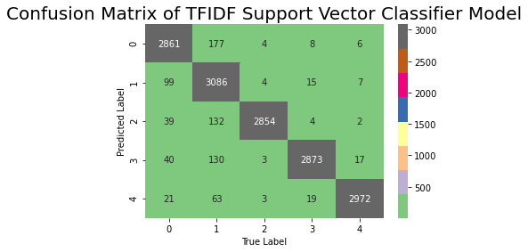

```
{0: 'DC Extended Universe', 1: 'Marvel Cinematic Universe', 2: 'MonsterVerse', 3: 'Star Wars', 4: 'Wizarding World'}
------------------------------------------------------------------------------------------------------------------------
('              precision    recall  f1-score   support\n'
 '\n'
 '           0       0.93      0.94      0.94      3056\n'
 '           1       0.86      0.96      0.91      3211\n'
 '           2       1.00      0.94      0.97      3031\n'
 '           3       0.98      0.94      0.96      3063\n'
 '           4       0.99      0.97      0.98      3078\n'
 '\n'
 '    accuracy                           0.95     15439\n'
 '   macro avg       0.95      0.95      0.95     15439\n'
 'weighted avg       0.95      0.95      0.95     15439\n')
Wall time: 3min 5s
```

```python
%%time
tfidf_svc_model = SVC()
tfidf_svc_model, score_tfidf_svc = evaluate_model(X_train_sv, y_train_sv, X_test_sv, y_test_sv, classes,
                                         tfidf_svc_model, "TFIDF Support Vector Classifier", "tfidf_svc_model.pkl", fresh_load=False)
```

```python
tf_idf_vectorizer = load(open('models/tfidf_stem_vector.pkl', 'rb'))
tfidf_svc_model = load(open('models/tfidf_svc_model.pkl', 'rb'))
```

```python
list_f = sorted(glob.glob("output/final_output/df_rottentomatoes_reviews_predicted*"), key=os.path.getmtime)
output_file_name = list_f[0]
df_rottentomatoes_reviews = pd.read_csv(output_file_name)
```

```python
%%time
val_acc_scr_tfidf_svc, df_rottentomatoes_reviews = validate_model(tfidf_svc_model, "TFIDF Support Vector Classifier", "tfidf_svc", df_rottentomatoes_reviews, valid_tfidf_vec_list)
```

```
Validation Accuracy Score of TFIDF Support Vector Classifier Model created using stemmed tf_idf vector is:
 0.690566037735849
Wall time: 27.3 s
```

```python
df_rottentomatoes_reviews.to_csv(output_file_name, index = False)
df_rottentomatoes_reviews
```

|  | review | movie_name | label_name | predicted_label_MNB | y_true | y_pred_MNB | predicted_label_tfidf_svc | y_pred_tfidf_svc |
| --- | --- | --- | --- | --- | --- | --- | --- | --- |
| 0 | 2019's Godzilla: King of the Monsters, does pr... | godzilla_king_of_the_monsters_2019 | MonsterVerse | MonsterVerse | 2 | 2 | MonsterVerse | 2 |
| 1 | Shazam!, it's wonderful. It's a very well-dire... | shazam | DC Extended Universe | DC Extended Universe | 0 | 0 | DC Extended Universe | 0 |
| 2 | The crimes of Grindelwald is a very good film ... | fantastic_beasts_the_crimes_of_grindelwald | Wizarding World | Wizarding World | 4 | 4 | DC Extended Universe | 0 |
| 3 | An entertaining film with a great villain and ... | spider_man_homecoming | Marvel Cinematic Universe | Marvel Cinematic Universe | 1 | 1 | Marvel Cinematic Universe | 1 |
| 4 | Captain America: Civil War goes a darker direc... | captain_america_civil_war | Marvel Cinematic Universe | Marvel Cinematic Universe | 1 | 1 | Marvel Cinematic Universe | 1 |
| ... | ... | ... | ... | ... | ... | ... | ... | ... |
| 260 | Shazam is fun and entertaining! It succeeds in... | shazam | DC Extended Universe | DC Extended Universe | 0 | 0 | DC Extended Universe | 0 |
| 261 | Godzilla: King of the Monsters was the first M... | godzilla_king_of_the_monsters_2019 | MonsterVerse | MonsterVerse | 2 | 2 | MonsterVerse | 2 |
| 262 | Not quite top tier MCU, but very close. This i... | avengers_infinity_war | Marvel Cinematic Universe | Marvel Cinematic Universe | 1 | 1 | Marvel Cinematic Universe | 1 |
| 263 | There are a lot of mixed feeling about this mo... | thor_the_dark_world | Marvel Cinematic Universe | Marvel Cinematic Universe | 1 | 1 | Marvel Cinematic Universe | 1 |
| 264 | Skull Island is more Donkey Kong than King Kon... | kong_skull_island | MonsterVerse | MonsterVerse | 2 | 2 | MonsterVerse | 2 |

265 rows × 8 columns

# TFIDF KNN Classifier

```
------------------------------------------------------------------------------------------------------------------------
Train Accuracy Score of TFIDF K-Nearest Neighbor(KNN) model created using stemmed tf_idf vector is:
 0.6134691724731421
------------------------------------------------------------------------------------------------------------------------
Test Accuracy Score of TFIDF K-Nearest Neighbor(KNN) model created using stemmed tf_idf vector is:
 0.42263099941706067
------------------------------------------------------------------------------------------------------------------------
Confusion Matrix:
[[1756  775  376   92   57]
 [1046 1610  412   81   62]
 [1030  822 1031   90   58]
 [ 874  684  341 1113   51]
 [ 887  693  388   95 1015]]
```

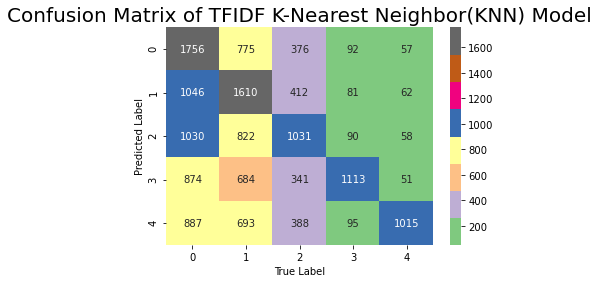

```
{0: 'DC Extended Universe', 1: 'Marvel Cinematic Universe', 2: 'MonsterVerse', 3: 'Star Wars', 4: 'Wizarding World'}
------------------------------------------------------------------------------------------------------------------------
('              precision    recall  f1-score   support\n'
 '\n'
 '           0       0.31      0.57      0.41      3056\n'
 '           1       0.35      0.50      0.41      3211\n'
 '           2       0.40      0.34      0.37      3031\n'
 '           3       0.76      0.36      0.49      3063\n'
 '           4       0.82      0.33      0.47      3078\n'
 '\n'
 '    accuracy                           0.42     15439\n'
 '   macro avg       0.53      0.42      0.43     15439\n'
 'weighted avg       0.53      0.42      0.43     15439\n')
Wall time: 59.3 s
```

```python
%%time
tfidf_knn_model = KNeighborsClassifier(5)
tfidf_knn_model, score_tfidf_knn = evaluate_model(X_train_sv, y_train_sv, X_test_sv, y_test_sv, classes,
                                         tfidf_knn_model, "TFIDF K-Nearest Neighbor(KNN)", "tfidf_knn_model.pkl", fresh_load=True)
```

```python
tf_idf_vectorizer = load(open('models/tfidf_stem_vector.pkl', 'rb'))
tfidf_knn_model = load(open('models/tfidf_knn_model.pkl', 'rb'))
```

```python
list_f = sorted(glob.glob("output/final_output/df_rottentomatoes_reviews_predicted*"), key=os.path.getmtime)
output_file_name = list_f[0]
df_rottentomatoes_reviews = pd.read_csv(output_file_name)
```

```python
%%time
val_acc_scr_tfidf_knn, df_rottentomatoes_reviews = validate_model(tfidf_knn_model, "TFIDF K-Nearest Neighbor(KNN)", "tfidf_knn", df_rottentomatoes_reviews, valid_tfidf_vec_list)
```

```
Validation Accuracy Score of TFIDF K-Nearest Neighbor(KNN) Model created using stemmed tf_idf vector is:
 0.5245283018867924
Wall time: 18.8 s
```

```python
%%time
get_cross_val(tfidf_knn_model, X_train_sv, y_train_sv, X_test_sv, y_test_sv)
```

```
Cross validation over 10 folds:  0.4237013220675041
Wall time: 41.8 s
```

```
array([2, 2, 0, ..., 0, 1, 0])
```

```python
df_rottentomatoes_reviews.to_csv(output_file_name, index = False)
df_rottentomatoes_reviews
```

|  | review | movie_name | label_name | predicted_label_MNB | y_true | y_pred_MNB | predicted_label_tfidf_xgb | y_pred_tfidf_xgb | predicted_label_tfidf_knn | y_pred_tfidf_knn |
| --- | --- | --- | --- | --- | --- | --- | --- | --- | --- | --- |
| 0 | 2019's Godzilla: King of the Monsters, does pr... | godzilla_king_of_the_monsters_2019 | MonsterVerse | MonsterVerse | 2 | 2 | MonsterVerse | 2 | MonsterVerse | 2 |
| 1 | Shazam!, it's wonderful. It's a very well-dire... | shazam | DC Extended Universe | DC Extended Universe | 0 | 0 | DC Extended Universe | 0 | DC Extended Universe | 0 |
| 2 | The crimes of Grindelwald is a very good film ... | fantastic_beasts_the_crimes_of_grindelwald | Wizarding World | Wizarding World | 4 | 4 | Marvel Cinematic Universe | 1 | Marvel Cinematic Universe | 1 |
| 3 | An entertaining film with a great villain and ... | spider_man_homecoming | Marvel Cinematic Universe | Marvel Cinematic Universe | 1 | 1 | Marvel Cinematic Universe | 1 | MonsterVerse | 2 |
| 4 | Captain America: Civil War goes a darker direc... | captain_america_civil_war | Marvel Cinematic Universe | Marvel Cinematic Universe | 1 | 1 | Marvel Cinematic Universe | 1 | Marvel Cinematic Universe | 1 |
| ... | ... | ... | ... | ... | ... | ... | ... | ... | ... | ... |
| 260 | Shazam is fun and entertaining! It succeeds in... | shazam | DC Extended Universe | DC Extended Universe | 0 | 0 | DC Extended Universe | 0 | DC Extended Universe | 0 |
| 261 | Godzilla: King of the Monsters was the first M... | godzilla_king_of_the_monsters_2019 | MonsterVerse | MonsterVerse | 2 | 2 | MonsterVerse | 2 | MonsterVerse | 2 |
| 262 | Not quite top tier MCU, but very close. This i... | avengers_infinity_war | Marvel Cinematic Universe | Marvel Cinematic Universe | 1 | 1 | Marvel Cinematic Universe | 1 | Marvel Cinematic Universe | 1 |
| 263 | There are a lot of mixed feeling about this mo... | thor_the_dark_world | Marvel Cinematic Universe | Marvel Cinematic Universe | 1 | 1 | Marvel Cinematic Universe | 1 | DC Extended Universe | 0 |
| 264 | Skull Island is more Donkey Kong than King Kon... | kong_skull_island | MonsterVerse | MonsterVerse | 2 | 2 | Marvel Cinematic Universe | 1 | Marvel Cinematic Universe | 1 |

265 rows × 10 columns

# TFIDF Random Forest Classifier

```
------------------------------------------------------------------------------------------------------------------------
Train Accuracy Score of TFIDF Random Forest Classifier model created using stemmed tf_idf vector is:
 0.9940038308858229
------------------------------------------------------------------------------------------------------------------------
Test Accuracy Score of TFIDF Random Forest Classifier model created using stemmed tf_idf vector is:
 0.9501910745514606
------------------------------------------------------------------------------------------------------------------------
Confusion Matrix:
[[2868  140   25   13   10]
 [ 122 3018   34   28    9]
 [  56   79 2881    7    8]
 [  58   68   18 2902   17]
 [  22   26    9   20 3001]]
```

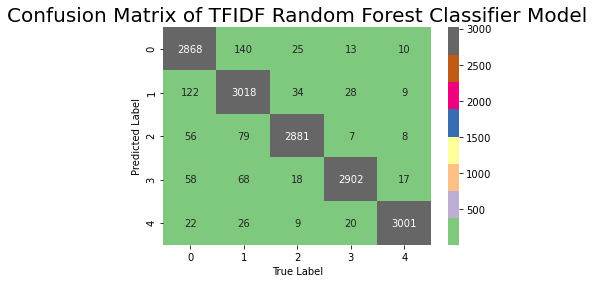

```
{0: 'DC Extended Universe', 1: 'Marvel Cinematic Universe', 2: 'MonsterVerse', 3: 'Star Wars', 4: 'Wizarding World'}
------------------------------------------------------------------------------------------------------------------------
('              precision    recall  f1-score   support\n'
 '\n'
 '           0       0.92      0.94      0.93      3056\n'
 '           1       0.91      0.94      0.92      3211\n'
 '           2       0.97      0.95      0.96      3031\n'
 '           3       0.98      0.95      0.96      3063\n'
 '           4       0.99      0.97      0.98      3078\n'
 '\n'
 '    accuracy                           0.95     15439\n'
 '   macro avg       0.95      0.95      0.95     15439\n'
 'weighted avg       0.95      0.95      0.95     15439\n')
Wall time: 1min 55s
```

```python
%%time
tfidf_rndm_frst_model = RandomForestClassifier(n_estimators=50)
tfidf_rndm_frst_model, score_tfidf_rfc = evaluate_model(X_train_sv, y_train_sv, X_test_sv, y_test_sv, classes,
                                         tfidf_rndm_frst_model, "TFIDF Random Forest Classifier", "tfidf_rndm_frst_model.pkl", fresh_load=True)
```

```python
tf_idf_vectorizer = load(open('models/tfidf_stem_vector.pkl', 'rb'))
tfidf_rndm_frst_model = load(open('models/tfidf_rndm_frst_model.pkl', 'rb'))
```

```python
list_f = sorted(glob.glob("output/final_output/df_rottentomatoes_reviews_predicted*"), key=os.path.getmtime)
output_file_name = list_f[0]
df_rottentomatoes_reviews = pd.read_csv(output_file_name)
```

```python
%%time
val_acc_scr_tfidf_rfc, df_rottentomatoes_reviews = validate_model(tfidf_rndm_frst_model, "TFIDF Random Forest Classifier", "tfidf_rfc", df_rottentomatoes_reviews, valid_tfidf_vec_list)
```

```
Validation Accuracy Score of TFIDF Random Forest Classifier Model created using stemmed tf_idf vector is:
 0.5962264150943396
Wall time: 5.16 s
```

```python
#%%time
#get_cross_val(tfidf_rndm_frst_model, X_train_sv, y_train_sv, X_test_sv, y_test_sv)
```

```python
df_rottentomatoes_reviews.to_csv(output_file_name, index = False)
df_rottentomatoes_reviews
```

|  | review | movie_name | label_name | predicted_label_MNB | y_true | y_pred_MNB | predicted_label_tfidf_rfc | y_pred_tfidf_rfc | predicted_label_tfidf_MNB | y_pred_tfidf_MNB |
| --- | --- | --- | --- | --- | --- | --- | --- | --- | --- | --- |
| 0 | 2019's Godzilla: King of the Monsters, does pr... | godzilla_king_of_the_monsters_2019 | MonsterVerse | MonsterVerse | 2 | 2 | MonsterVerse | 2 | MonsterVerse | 2 |
| 1 | Shazam!, it's wonderful. It's a very well-dire... | shazam | DC Extended Universe | DC Extended Universe | 0 | 0 | DC Extended Universe | 0 | DC Extended Universe | 0 |
| 2 | The crimes of Grindelwald is a very good film ... | fantastic_beasts_the_crimes_of_grindelwald | Wizarding World | Wizarding World | 4 | 4 | MonsterVerse | 2 | Wizarding World | 4 |
| 3 | An entertaining film with a great villain and ... | spider_man_homecoming | Marvel Cinematic Universe | Marvel Cinematic Universe | 1 | 1 | DC Extended Universe | 0 | Marvel Cinematic Universe | 1 |
| 4 | Captain America: Civil War goes a darker direc... | captain_america_civil_war | Marvel Cinematic Universe | Marvel Cinematic Universe | 1 | 1 | Marvel Cinematic Universe | 1 | Marvel Cinematic Universe | 1 |
| ... | ... | ... | ... | ... | ... | ... | ... | ... | ... | ... |
| 260 | Shazam is fun and entertaining! It succeeds in... | shazam | DC Extended Universe | DC Extended Universe | 0 | 0 | DC Extended Universe | 0 | DC Extended Universe | 0 |
| 261 | Godzilla: King of the Monsters was the first M... | godzilla_king_of_the_monsters_2019 | MonsterVerse | MonsterVerse | 2 | 2 | MonsterVerse | 2 | MonsterVerse | 2 |
| 262 | Not quite top tier MCU, but very close. This i... | avengers_infinity_war | Marvel Cinematic Universe | Marvel Cinematic Universe | 1 | 1 | DC Extended Universe | 0 | Marvel Cinematic Universe | 1 |
| 263 | There are a lot of mixed feeling about this mo... | thor_the_dark_world | Marvel Cinematic Universe | Marvel Cinematic Universe | 1 | 1 | DC Extended Universe | 0 | Marvel Cinematic Universe | 1 |
| 264 | Skull Island is more Donkey Kong than King Kon... | kong_skull_island | MonsterVerse | MonsterVerse | 2 | 2 | MonsterVerse | 2 | MonsterVerse | 2 |

265 rows × 10 columns

# TFIDF XG-Boost Classifier

```
------------------------------------------------------------------------------------------------------------------------
Train Accuracy Score of TFIDF XGB Classifier model created using stemmed tf_idf vector is:
 0.9471171196180218
------------------------------------------------------------------------------------------------------------------------
Test Accuracy Score of TFIDF XGB Classifier model created using stemmed tf_idf vector is:
 0.9419651531834964
------------------------------------------------------------------------------------------------------------------------
Confusion Matrix:
[[2737  299    5    9    6]
 [  30 3153    4   17    7]
 [   3  198 2824    3    3]
 [   7  169    1 2869   17]
 [   6   97    0   15 2960]]
```

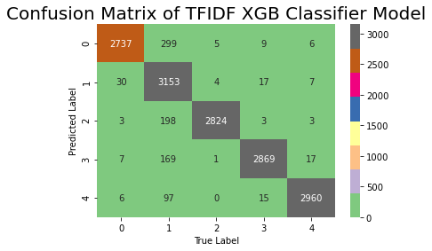

```
{0: 'DC Extended Universe', 1: 'Marvel Cinematic Universe', 2: 'MonsterVerse', 3: 'Star Wars', 4: 'Wizarding World'}
------------------------------------------------------------------------------------------------------------------------
('              precision    recall  f1-score   support\n'
 '\n'
 '           0       0.98      0.90      0.94      3056\n'
 '           1       0.81      0.98      0.88      3211\n'
 '           2       1.00      0.93      0.96      3031\n'
 '           3       0.98      0.94      0.96      3063\n'
 '           4       0.99      0.96      0.98      3078\n'
 '\n'
 '    accuracy                           0.94     15439\n'
 '   macro avg       0.95      0.94      0.94     15439\n'
 'weighted avg       0.95      0.94      0.94     15439\n')
Wall time: 47.1 s
```

```python
%%time
tfidf_xgb_model = xgb.XGBClassifier(
        learning_rate=0.1,
        max_depth=7,
        n_estimators=80,
        use_label_encoder=False,
        eval_metric='auc')
tfidf_xgb_model, score_tfidf_xgb = evaluate_model(X_train_sv, y_train_sv, X_test_sv, y_test_sv, classes,
                                         tfidf_xgb_model, "TFIDF XGB Classifier", "tfidf_xgb_model.pkl", fresh_load=True)
```

```python
tf_idf_vectorizer = load(open('models/tfidf_stem_vector.pkl', 'rb'))
tfidf_xgb_model = load(open('models/tfidf_xgb_model.pkl', 'rb'))
```

```python
list_f = sorted(glob.glob("output/final_output/df_rottentomatoes_reviews_predicted*"), key=os.path.getmtime)
output_file_name = list_f[0]
df_rottentomatoes_reviews = pd.read_csv(output_file_name)
```

```python
%%time
val_acc_scr_tfidf_xgb, df_rottentomatoes_reviews = validate_model(tfidf_xgb_model, "TFIDF XGB Classifier", "tfidf_xgb", df_rottentomatoes_reviews, valid_tfidf_vec_list)
```

```
Validation Accuracy Score of TFIDF XGB Classifier Model created using stemmed tf_idf vector is:
 0.7283018867924528
Wall time: 11 s
```

```python
#%%time
#get_cross_val(tfidf_xgb_model, X_train_sv, y_train_sv, X_test_sv, y_test_sv)
```

[output not shown]

[output not shown]

```python
df_rottentomatoes_reviews.to_csv(output_file_name, index = False)
df_rottentomatoes_reviews
```

|  | review | movie_name | label_name | predicted_label_MNB | y_true | y_pred_MNB | predicted_label_svc | y_pred_svc | predicted_label_knn | y_pred_knn | predicted_label_tfidf_svc | y_pred_tfidf_svc | predicted_label_tfidf_xgb | y_pred_tfidf_xgb |
| --- | --- | --- | --- | --- | --- | --- | --- | --- | --- | --- | --- | --- | --- | --- |
| 0 | 2019's Godzilla: King of the Monsters, does pr... | godzilla_king_of_the_monsters_2019 | MonsterVerse | MonsterVerse | 2 | 2 | MonsterVerse | 2 | MonsterVerse | 2 | MonsterVerse | 2 | MonsterVerse | 2 |
| 1 | Shazam!, it's wonderful. It's a very well-dire... | shazam | DC Extended Universe | DC Extended Universe | 0 | 0 | DC Extended Universe | 0 | DC Extended Universe | 0 | DC Extended Universe | 0 | DC Extended Universe | 0 |
| 2 | The crimes of Grindelwald is a very good film ... | fantastic_beasts_the_crimes_of_grindelwald | Wizarding World | Wizarding World | 4 | 4 | DC Extended Universe | 0 | Marvel Cinematic Universe | 1 | DC Extended Universe | 0 | Marvel Cinematic Universe | 1 |
| 3 | An entertaining film with a great villain and ... | spider_man_homecoming | Marvel Cinematic Universe | Marvel Cinematic Universe | 1 | 1 | Marvel Cinematic Universe | 1 | MonsterVerse | 2 | Marvel Cinematic Universe | 1 | Marvel Cinematic Universe | 1 |
| 4 | Captain America: Civil War goes a darker direc... | captain_america_civil_war | Marvel Cinematic Universe | Marvel Cinematic Universe | 1 | 1 | Marvel Cinematic Universe | 1 | Marvel Cinematic Universe | 1 | Marvel Cinematic Universe | 1 | Marvel Cinematic Universe | 1 |
| ... | ... | ... | ... | ... | ... | ... | ... | ... | ... | ... | ... | ... | ... | ... |
| 260 | Shazam is fun and entertaining! It succeeds in... | shazam | DC Extended Universe | DC Extended Universe | 0 | 0 | DC Extended Universe | 0 | DC Extended Universe | 0 | DC Extended Universe | 0 | DC Extended Universe | 0 |
| 261 | Godzilla: King of the Monsters was the first M... | godzilla_king_of_the_monsters_2019 | MonsterVerse | MonsterVerse | 2 | 2 | MonsterVerse | 2 | MonsterVerse | 2 | MonsterVerse | 2 | MonsterVerse | 2 |
| 262 | Not quite top tier MCU, but very close. This i... | avengers_infinity_war | Marvel Cinematic Universe | Marvel Cinematic Universe | 1 | 1 | Marvel Cinematic Universe | 1 | Marvel Cinematic Universe | 1 | Marvel Cinematic Universe | 1 | Marvel Cinematic Universe | 1 |
| 263 | There are a lot of mixed feeling about this mo... | thor_the_dark_world | Marvel Cinematic Universe | Marvel Cinematic Universe | 1 | 1 | Marvel Cinematic Universe | 1 | DC Extended Universe | 0 | Marvel Cinematic Universe | 1 | Marvel Cinematic Universe | 1 |
| 264 | Skull Island is more Donkey Kong than King Kon... | kong_skull_island | MonsterVerse | MonsterVerse | 2 | 2 | MonsterVerse | 2 | Marvel Cinematic Universe | 1 | MonsterVerse | 2 | Marvel Cinematic Universe | 1 |

265 rows × 14 columns

```python
score_tfidf_mnb.append(val_acc_scr_tfidf_mnb)
score_tfidf_svc.append(val_acc_scr_tfidf_svc)
score_tfidf_knn.append(val_acc_scr_tfidf_knn)
score_tfidf_rfc.append(val_acc_scr_tfidf_rfc)
score_tfidf_xgb.append(val_acc_scr_tfidf_xgb)
score = score_tfidf_mnb
score.extend(score_tfidf_svc)
score.extend(score_tfidf_knn)
score.extend(score_tfidf_rfc)
score.extend(score_tfidf_xgb)
score = [score]
```

```python
df_score = pd.DataFrame(score)
df_score.columns = pd.MultiIndex.from_product([['MNB Accuracy', 'SVC Accuracy', 'KNN Accuracy', 'RFC Accuracy', 'XGB Accuracy'], ['Train','Test','Validate']])
df_score = df_score.set_index([['Basic Vectorisation']])
df_score[df_score.columns] = df_score[df_score.columns].applymap("{0:.2f}%".format)
df_score
```

|  | MNB Accuracy Train | MNB Accuracy Test | MNB Accuracy Validate | SVC Accuracy Train | SVC Accuracy Test | SVC Accuracy Validate | KNN Accuracy Train | KNN Accuracy Test | KNN Accuracy Validate | RFC Accuracy Train | RFC Accuracy Test | RFC Accuracy Validate | XGB Accuracy Train | XGB Accuracy Test | XGB Accuracy Validate |
| --- | --- | --- | --- | --- | --- | --- | --- | --- | --- | --- | --- | --- | --- | --- | --- |
| Basic Vectorisation | 0.97% | 0.94% | 0.78% | 0.99% | 0.95% | 0.69% | 0.61% | 0.42% | 0.52% | 0.99% | 0.95% | 0.60% | 0.95% | 0.94% | 0.73% |

# Document Embeddings

```python
df_embedding.head()
```

|  | lemma_cleaned_tokens | label | label_id |
| --- | --- | --- | --- |
| 0 | ['guardiansofthegalaxy', 'star', 'karengillan'... | Marvel Cinematic Universe | 1 |
| 1 | ['friend', 'show', 'idea', 'flash', 'guy', 'id... | DC Extended Universe | 0 |
| 2 | ['papa', 'drago', 'godzilla', 'tear', 'hundred... | MonsterVerse | 2 |
| 3 | ['batman', 'robin', 'camp'] | DC Extended Universe | 0 |
| 4 | ['huge', 'ant', 'man', 'slow'] | Marvel Cinematic Universe | 1 |

```python
print(list_embedding_data[:5])
```

```
[['guardiansofthegalaxy', 'star', 'karengillan', 'improvised', 'lot', 'line', 'marvel', 'threequel'], ['friend', 'show', 'idea', 'flash', 'guy', 'idk', 'show', 'watch', 'vote', 'idk', 'hour', 'pick', 'smt', 'good'], ['papa', 'drago', 'godzilla', 'tear', 'hundred', 'titan', 'cool', 'omg'], ['batman',…
```

```python
X_emb = list_embedding_data
y_emb = df_embedding.label_id
X_train_emb, X_test_emb, y_train_emb, y_test_emb = train_test_split(X_emb, y_emb, test_size = 0.3, shuffle = True, stratify = y_emb, random_state = 3)
```

```python
w2v_model = Word2Vec(X_emb,
                     vector_size=100,
                     window=5,
                     min_count=2,
                     sg=1)
```

```python
words = ['star','vader','flash','batman','ironman','thanos','harry','godzilla','kong','king']
for i in range(len(words)):
    print(words[i], end="\t==>  ")
    similar = w2v_model.wv.most_similar(words[i], topn = 10)
    for j in range(len(similar)):
        print(similar[j][0],end =", ")
    print("\n")
```

```
star	==>  war, battlefront, radious, finnpoe, lucasfilm, skywalk, merchandise, merchandising, lswgame, romudeth,

vader	==>  darth, maul, emperor, sidious, prowse, palpatine, apprentice, lightsaber, staybombastic, padm,

flash	==>  drive, bale, rainfall, coupon, regular, texas, price, cyborg, filmchallenge, mpd,

batman	==>  riddler, robin, catwoman, gotham, arkham, dceu, batgirl, thebatman, penguin, pattinson,

ironman	==>  robertdowneyjr, tonystark, happybirthdayrobertdowneyjr, rdj, happybirthdayrdj, avengersendgame, marvelsavengers, chaplin, infinitywar, wolverine,

thanos	==>  verybadllama, slim, infinity, snap, gauntlet, brolin, pagkidis, nebula, gamora, xandar,

harry	==>  potter, rowling, slytherin, azkaban, sorteiopromodebooks, fcbarcelona, harrypotter, dobby, goblet, mcyt,

godzilla	==>  kaiju, mechagodzilla, toho, godzillavskong, mecha, shin, anguirus, mothra, monsterverse, ghidorah,

kong	==>  king, bundy, ape, island, diamond, godzillavskong, skull, roar, babar, paw,

king	==>  kong, bundy, diamond, paw, babar, icppark, donkey, roar, ape, drift,
```

```python
dump(w2v_model, open("models/w2v_lemma_embedding.model", 'wb'))
```

```python
w2v_model = Word2Vec.load("models/w2v_lemma_embedding.model")
```

```python
%%time
# load the pre-trained word-embedding vectors
embeddings_index = {} #converting glove file to dictionary
path = "G:\spark_big_files\glove.6B\\"
glove_6B_300d_file = path+'glove.6B.300d.txt'
x_train_emb_seq, x_test_emb_seq, embedding_matrix =  glove_wrd_emb(glove_6B_300d_file, X_emb, X_train_emb, X_test_emb)
```

```
Wall time: 32 s
```

```python
x_train_emb_seq.shape
```

```
(36023, 300)
```

# Word Embedding Multinomial Naive Bayes model

```
------------------------------------------------------------------------------------------------------------------------
Train Accuracy Score of Word Embedding Multinomial Naive Bayes model created using stemmed tf_idf vector is:
 0.21241984287816118
------------------------------------------------------------------------------------------------------------------------
Test Accuracy Score of Word Embedding Multinomial Naive Bayes model created using stemmed tf_idf vector is:
 0.2132262452231362
------------------------------------------------------------------------------------------------------------------------
Confusion Matrix:
[[ 108   77 2764   85   22]
 [  79  192 2842   83   15]
 [  68   32 2847   57   27]
 [  93   77 2746  120   27]
 [  84   74 2835   60   25]]
```

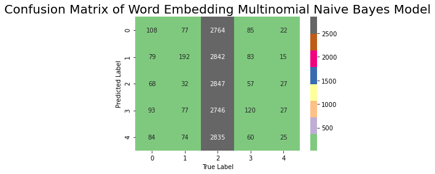

```
{0: 'DC Extended Universe', 1: 'Marvel Cinematic Universe', 2: 'MonsterVerse', 3: 'Star Wars', 4: 'Wizarding World'}
------------------------------------------------------------------------------------------------------------------------
('              precision    recall  f1-score   support\n'
 '\n'
 '           0       0.25      0.04      0.06      3056\n'
 '           1       0.42      0.06      0.10      3211\n'
 '           2       0.20      0.94      0.33      3031\n'
 '           3       0.30      0.04      0.07      3063\n'
 '           4       0.22      0.01      0.02      3078\n'
 '\n'
 '    accuracy                           0.21     15439\n'
 '   macro avg       0.28      0.22      0.12     15439\n'
 'weighted avg       0.28      0.21      0.12     15439\n')
Wall time: 676 ms
```

```python
%%time
we_multi_naive_bayes_model = MultinomialNB()
we_multi_naive_bayes_model, score_we_mnb = evaluate_model(x_train_emb_seq, y_train_emb, x_test_emb_seq, y_test_emb, classes,
                                         we_multi_naive_bayes_model, "Word Embedding Multinomial Naive Bayes", "we_multi_naive_bayes_model.pkl", fresh_load=True)
```

```python
list_f = sorted(glob.glob("output/final_output/df_rottentomatoes_reviews_predicted*"), key=os.path.getmtime)
output_file_name = list_f[0]
df_rottentomatoes_reviews = pd.read_csv(output_file_name)
```

```python
%%time
X_valid_emb = []
tags = ['NN','NNP','NNPS','NNS','JJ','JJR','JJS']
classes = {0: 'DC Extended Universe', 1: 'Marvel Cinematic Universe', 2: 'MonsterVerse', 3: 'Star Wars', 4: 'Wizarding World'}
for i in df_rottentomatoes_reviews.index:
    validation_text = df_rottentomatoes_reviews["review"][i]
    validation_text = preprocess_doc(validation_text, stem = False, lemma = True, stop_wrds = True, selected_tags = tags)
    X_valid_emb.append(validation_text)
x_valid_emb_seq, temp, embedding_matrix =  glove_wrd_emb(glove_6B_300d_file, X_emb, X_valid_emb, [])
```

```
Wall time: 41 s
```

```python
%%time
val_acc_scr_we_mnb, df_rottentomatoes_reviews = validate_wrd_emb_model(we_multi_naive_bayes_model, "Word embedded Multinomial Naive Bayes Model", "we_mnb",
                                                                df_rottentomatoes_reviews, x_valid_emb_seq)
```

```
Validation Accuracy Score of Word embedded Multinomial Naive Bayes Model Model created using lemmatized word embedding vector is:
 0.2679245283018868
Wall time: 25.9 ms
```

```python
df_rottentomatoes_reviews.to_csv(output_file_name, index = False)
df_rottentomatoes_reviews
```

|  | review | movie_name | label_name | predicted_label_MNB | y_true | y_pred_MNB | predicted_label_knn | y_pred_knn | predicted_label_tfidf_knn | y_pred_tfidf_knn | predicted_label_we_mnb | y_pred_we_mnb |
| --- | --- | --- | --- | --- | --- | --- | --- | --- | --- | --- | --- | --- |
| 0 | 2019's Godzilla: King of the Monsters, does pr... | godzilla_king_of_the_monsters_2019 | MonsterVerse | MonsterVerse | 2 | 2 | MonsterVerse | 2 | MonsterVerse | 2 | Marvel Cinematic Universe | 1 |
| 1 | Shazam!, it's wonderful. It's a very well-dire... | shazam | DC Extended Universe | DC Extended Universe | 0 | 0 | DC Extended Universe | 0 | DC Extended Universe | 0 | Wizarding World | 4 |
| 2 | The crimes of Grindelwald is a very good film ... | fantastic_beasts_the_crimes_of_grindelwald | Wizarding World | Wizarding World | 4 | 4 | Marvel Cinematic Universe | 1 | Marvel Cinematic Universe | 1 | Marvel Cinematic Universe | 1 |
| 3 | An entertaining film with a great villain and ... | spider_man_homecoming | Marvel Cinematic Universe | Marvel Cinematic Universe | 1 | 1 | MonsterVerse | 2 | MonsterVerse | 2 | Star Wars | 3 |
| 4 | Captain America: Civil War goes a darker direc... | captain_america_civil_war | Marvel Cinematic Universe | Marvel Cinematic Universe | 1 | 1 | Marvel Cinematic Universe | 1 | Marvel Cinematic Universe | 1 | Star Wars | 3 |
| ... | ... | ... | ... | ... | ... | ... | ... | ... | ... | ... | ... | ... |
| 260 | Shazam is fun and entertaining! It succeeds in... | shazam | DC Extended Universe | DC Extended Universe | 0 | 0 | DC Extended Universe | 0 | DC Extended Universe | 0 | Marvel Cinematic Universe | 1 |
| 261 | Godzilla: King of the Monsters was the first M... | godzilla_king_of_the_monsters_2019 | MonsterVerse | MonsterVerse | 2 | 2 | MonsterVerse | 2 | MonsterVerse | 2 | Marvel Cinematic Universe | 1 |
| 262 | Not quite top tier MCU, but very close. This i... | avengers_infinity_war | Marvel Cinematic Universe | Marvel Cinematic Universe | 1 | 1 | Marvel Cinematic Universe | 1 | Marvel Cinematic Universe | 1 | MonsterVerse | 2 |
| 263 | There are a lot of mixed feeling about this mo... | thor_the_dark_world | Marvel Cinematic Universe | Marvel Cinematic Universe | 1 | 1 | DC Extended Universe | 0 | DC Extended Universe | 0 | Star Wars | 3 |
| 264 | Skull Island is more Donkey Kong than King Kon... | kong_skull_island | MonsterVerse | MonsterVerse | 2 | 2 | Marvel Cinematic Universe | 1 | Marvel Cinematic Universe | 1 | Marvel Cinematic Universe | 1 |

265 rows × 12 columns

# Word Embedding Support Vector Classifier

```
------------------------------------------------------------------------------------------------------------------------
Train Accuracy Score of Word Embedding Support Vector Classifier model created using stemmed tf_idf vector is:
 0.3121061544013547
------------------------------------------------------------------------------------------------------------------------
Test Accuracy Score of Word Embedding Support Vector Classifier model created using stemmed tf_idf vector is:
 0.23919943001489732
------------------------------------------------------------------------------------------------------------------------
Confusion Matrix:
[[ 469  405  689 1152  341]
 [ 381  464  632 1388  346]
 [ 361  330  722 1230  388]
 [ 267  290  516 1677  313]
 [ 357  316  595 1449  361]]
```

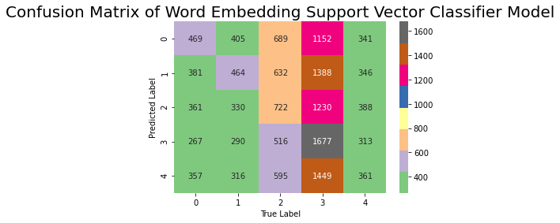

```
{0: 'DC Extended Universe', 1: 'Marvel Cinematic Universe', 2: 'MonsterVerse', 3: 'Star Wars', 4: 'Wizarding World'}
------------------------------------------------------------------------------------------------------------------------
('              precision    recall  f1-score   support\n'
 '\n'
 '           0       0.26      0.15      0.19      3056\n'
 '           1       0.26      0.14      0.19      3211\n'
 '           2       0.23      0.24      0.23      3031\n'
 '           3       0.24      0.55      0.34      3063\n'
 '           4       0.21      0.12      0.15      3078\n'
 '\n'
 '    accuracy                           0.24     15439\n'
 '   macro avg       0.24      0.24      0.22     15439\n'
 'weighted avg       0.24      0.24      0.22     15439\n')
Wall time: 38min 15s
```

```python
%%time
wrd_emb_svc_model = SVC(kernel='rbf')
wrd_emb_svc_model, score_we_svc = evaluate_model(x_train_emb_seq, y_train_emb, x_test_emb_seq, y_test_emb, classes,
                                         wrd_emb_svc_model, "Word Embedding Support Vector Classifier", "wrd_emb_svc_model.pkl", fresh_load=False)
```

```python
list_f = sorted(glob.glob("output/final_output/df_rottentomatoes_reviews_predicted*"), key=os.path.getmtime)
output_file_name = list_f[0]
df_rottentomatoes_reviews = pd.read_csv(output_file_name)
```

```python
%%time
val_acc_scr_we_svc, df_rottentomatoes_reviews = validate_wrd_emb_model(wrd_emb_svc_model, "Word Embedding Support Vector Classifier", "we_svc",
                                                                df_rottentomatoes_reviews, x_valid_emb_seq)
```

```
Validation Accuracy Score of Word Embedding Support Vector Classifier Model created using lemmatized word embedding vector is:
 0.2641509433962264
Wall time: 5.72 s
```

```python
df_rottentomatoes_reviews.to_csv(output_file_name, index = False)
df_rottentomatoes_reviews
```

|  | review | movie_name | label_name | predicted_label_MNB | y_true | y_pred_MNB | predicted_label_knn | y_pred_knn | predicted_label_svc | y_pred_svc | predicted_label_tfidf_rfc | y_pred_tfidf_rfc | predicted_label_we_svc | y_pred_we_svc |
| --- | --- | --- | --- | --- | --- | --- | --- | --- | --- | --- | --- | --- | --- | --- |
| 0 | 2019's Godzilla: King of the Monsters, does pr... | godzilla_king_of_the_monsters_2019 | MonsterVerse | MonsterVerse | 2 | 2 | MonsterVerse | 2 | MonsterVerse | 2 | MonsterVerse | 2 | Marvel Cinematic Universe | 1 |
| 1 | Shazam!, it's wonderful. It's a very well-dire... | shazam | DC Extended Universe | DC Extended Universe | 0 | 0 | DC Extended Universe | 0 | DC Extended Universe | 0 | DC Extended Universe | 0 | Star Wars | 3 |
| 2 | The crimes of Grindelwald is a very good film ... | fantastic_beasts_the_crimes_of_grindelwald | Wizarding World | Wizarding World | 4 | 4 | Marvel Cinematic Universe | 1 | DC Extended Universe | 0 | MonsterVerse | 2 | Star Wars | 3 |
| 3 | An entertaining film with a great villain and ... | spider_man_homecoming | Marvel Cinematic Universe | Marvel Cinematic Universe | 1 | 1 | MonsterVerse | 2 | Marvel Cinematic Universe | 1 | DC Extended Universe | 0 | Star Wars | 3 |
| 4 | Captain America: Civil War goes a darker direc... | captain_america_civil_war | Marvel Cinematic Universe | Marvel Cinematic Universe | 1 | 1 | Marvel Cinematic Universe | 1 | Marvel Cinematic Universe | 1 | Marvel Cinematic Universe | 1 | Star Wars | 3 |
| ... | ... | ... | ... | ... | ... | ... | ... | ... | ... | ... | ... | ... | ... | ... |
| 260 | Shazam is fun and entertaining! It succeeds in... | shazam | DC Extended Universe | DC Extended Universe | 0 | 0 | DC Extended Universe | 0 | DC Extended Universe | 0 | DC Extended Universe | 0 | Marvel Cinematic Universe | 1 |
| 261 | Godzilla: King of the Monsters was the first M... | godzilla_king_of_the_monsters_2019 | MonsterVerse | MonsterVerse | 2 | 2 | MonsterVerse | 2 | MonsterVerse | 2 | MonsterVerse | 2 | Marvel Cinematic Universe | 1 |
| 262 | Not quite top tier MCU, but very close. This i... | avengers_infinity_war | Marvel Cinematic Universe | Marvel Cinematic Universe | 1 | 1 | Marvel Cinematic Universe | 1 | Marvel Cinematic Universe | 1 | DC Extended Universe | 0 | DC Extended Universe | 0 |
| 263 | There are a lot of mixed feeling about this mo... | thor_the_dark_world | Marvel Cinematic Universe | Marvel Cinematic Universe | 1 | 1 | DC Extended Universe | 0 | Marvel Cinematic Universe | 1 | Marvel Cinematic Universe | 1 | Star Wars | 3 |
| 264 | Skull Island is more Donkey Kong than King Kon... | kong_skull_island | MonsterVerse | MonsterVerse | 2 | 2 | Marvel Cinematic Universe | 1 | MonsterVerse | 2 | Marvel Cinematic Universe | 1 | Marvel Cinematic Universe | 1 |

265 rows × 14 columns

# Word Embedding K-Nearest Neighbor(KNN)

```
------------------------------------------------------------------------------------------------------------------------
Train Accuracy Score of Word Embedding K-Nearest Neighbor(KNN) model created using stemmed tf_idf vector is:
 0.5111178968992033
------------------------------------------------------------------------------------------------------------------------
Test Accuracy Score of Word Embedding K-Nearest Neighbor(KNN) model created using stemmed tf_idf vector is:
 0.2864822851220934
------------------------------------------------------------------------------------------------------------------------
Confusion Matrix:
[[1056  649  578  412  361]
 [ 828  958  520  513  392]
 [ 769  657  784  427  394]
 [ 660  608  470  957  368]
 [ 710  629  535  536  668]]
```

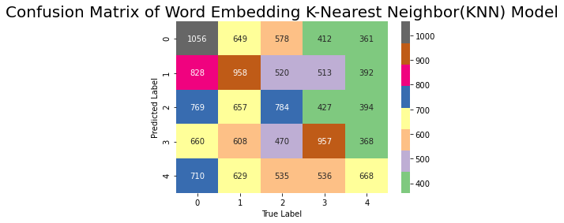

```
{0: 'DC Extended Universe', 1: 'Marvel Cinematic Universe', 2: 'MonsterVerse', 3: 'Star Wars', 4: 'Wizarding World'}
------------------------------------------------------------------------------------------------------------------------
('              precision    recall  f1-score   support\n'
 '\n'
 '           0       0.26      0.35      0.30      3056\n'
 '           1       0.27      0.30      0.29      3211\n'
 '           2       0.27      0.26      0.26      3031\n'
 '           3       0.34      0.31      0.32      3063\n'
 '           4       0.31      0.22      0.25      3078\n'
 '\n'
 '    accuracy                           0.29     15439\n'
 '   macro avg       0.29      0.29      0.29     15439\n'
 'weighted avg       0.29      0.29      0.29     15439\n')
Wall time: 2min 5s
```

```python
%%time
wrd_emb_knn_model = KNeighborsClassifier(5)
wrd_emb_knn_model, score_we_knn = evaluate_model(x_train_emb_seq, y_train_emb, x_test_emb_seq, y_test_emb, classes,
                                         wrd_emb_knn_model, "Word Embedding K-Nearest Neighbor(KNN)", "wrd_emb_knn_model.pkl", fresh_load=True)
```

```python
%%time
val_acc_scr_we_knn, df_rottentomatoes_reviews = validate_wrd_emb_model(wrd_emb_knn_model, "Word Embedding K-Nearest Neighbor(KNN)", "we_knn",
                                                                df_rottentomatoes_reviews, x_valid_emb_seq)
```

```
Validation Accuracy Score of Word Embedding K-Nearest Neighbor(KNN) Model created using lemmatized word embedding vector is:
 0.2
Wall time: 32.6 s
```

```python
df_rottentomatoes_reviews.to_csv(output_file_name, index = False)
df_rottentomatoes_reviews
```

|  | review | movie_name | label_name | predicted_label_MNB | y_true | y_pred_MNB | predicted_label_knn | y_pred_knn | predicted_label_svc | y_pred_svc | predicted_label_tfidf_rfc | y_pred_tfidf_rfc | predicted_label_we_svc | y_pred_we_svc | predicted_label_we_knn | y_pred_we_knn |
| --- | --- | --- | --- | --- | --- | --- | --- | --- | --- | --- | --- | --- | --- | --- | --- | --- |
| 0 | 2019's Godzilla: King of the Monsters, does pr... | godzilla_king_of_the_monsters_2019 | MonsterVerse | MonsterVerse | 2 | 2 | MonsterVerse | 2 | MonsterVerse | 2 | MonsterVerse | 2 | Marvel Cinematic Universe | 1 | Star Wars | 3 |
| 1 | Shazam!, it's wonderful. It's a very well-dire... | shazam | DC Extended Universe | DC Extended Universe | 0 | 0 | DC Extended Universe | 0 | DC Extended Universe | 0 | DC Extended Universe | 0 | Star Wars | 3 | DC Extended Universe | 0 |
| 2 | The crimes of Grindelwald is a very good film ... | fantastic_beasts_the_crimes_of_grindelwald | Wizarding World | Wizarding World | 4 | 4 | Marvel Cinematic Universe | 1 | DC Extended Universe | 0 | MonsterVerse | 2 | Star Wars | 3 | MonsterVerse | 2 |
| 3 | An entertaining film with a great villain and ... | spider_man_homecoming | Marvel Cinematic Universe | Marvel Cinematic Universe | 1 | 1 | MonsterVerse | 2 | Marvel Cinematic Universe | 1 | DC Extended Universe | 0 | Star Wars | 3 | Wizarding World | 4 |
| 4 | Captain America: Civil War goes a darker direc... | captain_america_civil_war | Marvel Cinematic Universe | Marvel Cinematic Universe | 1 | 1 | Marvel Cinematic Universe | 1 | Marvel Cinematic Universe | 1 | Marvel Cinematic Universe | 1 | Star Wars | 3 | Wizarding World | 4 |
| ... | ... | ... | ... | ... | ... | ... | ... | ... | ... | ... | ... | ... | ... | ... | ... | ... |
| 260 | Shazam is fun and entertaining! It succeeds in... | shazam | DC Extended Universe | DC Extended Universe | 0 | 0 | DC Extended Universe | 0 | DC Extended Universe | 0 | DC Extended Universe | 0 | Marvel Cinematic Universe | 1 | DC Extended Universe | 0 |
| 261 | Godzilla: King of the Monsters was the first M... | godzilla_king_of_the_monsters_2019 | MonsterVerse | MonsterVerse | 2 | 2 | MonsterVerse | 2 | MonsterVerse | 2 | MonsterVerse | 2 | Marvel Cinematic Universe | 1 | Marvel Cinematic Universe | 1 |
| 262 | Not quite top tier MCU, but very close. This i... | avengers_infinity_war | Marvel Cinematic Universe | Marvel Cinematic Universe | 1 | 1 | Marvel Cinematic Universe | 1 | Marvel Cinematic Universe | 1 | DC Extended Universe | 0 | DC Extended Universe | 0 | Star Wars | 3 |
| 263 | There are a lot of mixed feeling about this mo... | thor_the_dark_world | Marvel Cinematic Universe | Marvel Cinematic Universe | 1 | 1 | DC Extended Universe | 0 | Marvel Cinematic Universe | 1 | Marvel Cinematic Universe | 1 | Star Wars | 3 | MonsterVerse | 2 |
| 264 | Skull Island is more Donkey Kong than King Kon... | kong_skull_island | MonsterVerse | MonsterVerse | 2 | 2 | Marvel Cinematic Universe | 1 | MonsterVerse | 2 | Marvel Cinematic Universe | 1 | Marvel Cinematic Universe | 1 | Marvel Cinematic Universe | 1 |

265 rows × 16 columns

# Word Embedding Random Forest Classifier

```
------------------------------------------------------------------------------------------------------------------------
Train Accuracy Score of Word Embedding Random Forest Classifier model created using stemmed tf_idf vector is:
 0.9952807928268051
------------------------------------------------------------------------------------------------------------------------
Test Accuracy Score of Word Embedding Random Forest Classifier model created using stemmed tf_idf vector is:
 0.7113154997085304
------------------------------------------------------------------------------------------------------------------------
Confusion Matrix:
[[1943  799  157   57  100]
 [ 589 2254  184   94   90]
 [ 258  395 2213   60  105]
 [ 206  358   42 2408   49]
 [ 296  447  112   59 2164]]
```

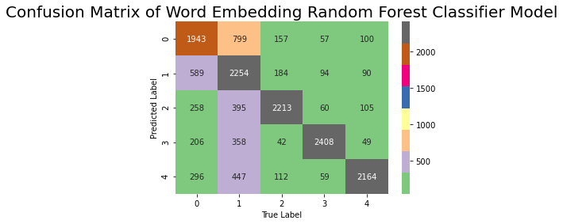

```
{0: 'DC Extended Universe', 1: 'Marvel Cinematic Universe', 2: 'MonsterVerse', 3: 'Star Wars', 4: 'Wizarding World'}
------------------------------------------------------------------------------------------------------------------------
('              precision    recall  f1-score   support\n'
 '\n'
 '           0       0.59      0.64      0.61      3056\n'
 '           1       0.53      0.70      0.60      3211\n'
 '           2       0.82      0.73      0.77      3031\n'
 '           3       0.90      0.79      0.84      3063\n'
 '           4       0.86      0.70      0.77      3078\n'
 '\n'
 '    accuracy                           0.71     15439\n'
 '   macro avg       0.74      0.71      0.72     15439\n'
 'weighted avg       0.74      0.71      0.72     15439\n')
Wall time: 1min 4s
```

```python
%%time
wrd_emb_rndm_frst_model = RandomForestClassifier(n_estimators=200)
wrd_emb_rndm_frst_model, score_we_rfc = evaluate_model(x_train_emb_seq, y_train_emb, x_test_emb_seq, y_test_emb, classes,
                                         wrd_emb_rndm_frst_model, "Word Embedding Random Forest Classifier", "wrd_emb_rndm_frst_model.pkl", fresh_load=True)
```

```python
%%time
val_acc_scr_we_rfc, df_rottentomatoes_reviews = validate_wrd_emb_model(wrd_emb_knn_model, "Word Embedding Random Forest Classifier", "we_rfc",
                                                                df_rottentomatoes_reviews, x_valid_emb_seq)
```

```
Validation Accuracy Score of Word Embedding Random Forest Classifier Model created using lemmatized word embedding vector is:
 0.2
Wall time: 32.5 s
```

```python
df_rottentomatoes_reviews.to_csv(output_file_name, index = False)
df_rottentomatoes_reviews
```

|  | review | movie_name | label_name | predicted_label_MNB | y_true | y_pred_MNB | predicted_label_knn | y_pred_knn | predicted_label_svc | y_pred_svc | predicted_label_tfidf_rfc | y_pred_tfidf_rfc | predicted_label_we_svc | y_pred_we_svc | predicted_label_we_knn | y_pred_we_knn | predicted_label_we_rfc | y_pred_we_rfc |
| --- | --- | --- | --- | --- | --- | --- | --- | --- | --- | --- | --- | --- | --- | --- | --- | --- | --- | --- |
| 0 | 2019's Godzilla: King of the Monsters, does pr... | godzilla_king_of_the_monsters_2019 | MonsterVerse | MonsterVerse | 2 | 2 | MonsterVerse | 2 | MonsterVerse | 2 | MonsterVerse | 2 | Marvel Cinematic Universe | 1 | Star Wars | 3 | Star Wars | 3 |
| 1 | Shazam!, it's wonderful. It's a very well-dire... | shazam | DC Extended Universe | DC Extended Universe | 0 | 0 | DC Extended Universe | 0 | DC Extended Universe | 0 | DC Extended Universe | 0 | Star Wars | 3 | DC Extended Universe | 0 | DC Extended Universe | 0 |
| 2 | The crimes of Grindelwald is a very good film ... | fantastic_beasts_the_crimes_of_grindelwald | Wizarding World | Wizarding World | 4 | 4 | Marvel Cinematic Universe | 1 | DC Extended Universe | 0 | MonsterVerse | 2 | Star Wars | 3 | MonsterVerse | 2 | MonsterVerse | 2 |
| 3 | An entertaining film with a great villain and ... | spider_man_homecoming | Marvel Cinematic Universe | Marvel Cinematic Universe | 1 | 1 | MonsterVerse | 2 | Marvel Cinematic Universe | 1 | DC Extended Universe | 0 | Star Wars | 3 | Wizarding World | 4 | Wizarding World | 4 |
| 4 | Captain America: Civil War goes a darker direc... | captain_america_civil_war | Marvel Cinematic Universe | Marvel Cinematic Universe | 1 | 1 | Marvel Cinematic Universe | 1 | Marvel Cinematic Universe | 1 | Marvel Cinematic Universe | 1 | Star Wars | 3 | Wizarding World | 4 | Wizarding World | 4 |
| ... | ... | ... | ... | ... | ... | ... | ... | ... | ... | ... | ... | ... | ... | ... | ... | ... | ... | ... |
| 260 | Shazam is fun and entertaining! It succeeds in... | shazam | DC Extended Universe | DC Extended Universe | 0 | 0 | DC Extended Universe | 0 | DC Extended Universe | 0 | DC Extended Universe | 0 | Marvel Cinematic Universe | 1 | DC Extended Universe | 0 | DC Extended Universe | 0 |
| 261 | Godzilla: King of the Monsters was the first M... | godzilla_king_of_the_monsters_2019 | MonsterVerse | MonsterVerse | 2 | 2 | MonsterVerse | 2 | MonsterVerse | 2 | MonsterVerse | 2 | Marvel Cinematic Universe | 1 | Marvel Cinematic Universe | 1 | Marvel Cinematic Universe | 1 |
| 262 | Not quite top tier MCU, but very close. This i... | avengers_infinity_war | Marvel Cinematic Universe | Marvel Cinematic Universe | 1 | 1 | Marvel Cinematic Universe | 1 | Marvel Cinematic Universe | 1 | DC Extended Universe | 0 | DC Extended Universe | 0 | Star Wars | 3 | Star Wars | 3 |
| 263 | There are a lot of mixed feeling about this mo... | thor_the_dark_world | Marvel Cinematic Universe | Marvel Cinematic Universe | 1 | 1 | DC Extended Universe | 0 | Marvel Cinematic Universe | 1 | Marvel Cinematic Universe | 1 | Star Wars | 3 | MonsterVerse | 2 | MonsterVerse | 2 |
| 264 | Skull Island is more Donkey Kong than King Kon... | kong_skull_island | MonsterVerse | MonsterVerse | 2 | 2 | Marvel Cinematic Universe | 1 | MonsterVerse | 2 | Marvel Cinematic Universe | 1 | Marvel Cinematic Universe | 1 | Marvel Cinematic Universe | 1 | Marvel Cinematic Universe | 1 |

265 rows × 18 columns

# Word Embedding XGB Classifier

```
------------------------------------------------------------------------------------------------------------------------
Train Accuracy Score of Word Embedding XGB Classifier model created using stemmed tf_idf vector is:
 0.8333564667018294
------------------------------------------------------------------------------------------------------------------------
Test Accuracy Score of Word Embedding XGB Classifier model created using stemmed tf_idf vector is:
 0.7762808472051299
------------------------------------------------------------------------------------------------------------------------
Confusion Matrix:
[[2259  667   25   27   78]
 [ 348 2711   21   64   67]
 [ 295  428 2233   23   52]
 [ 179  354   20 2454   56]
 [ 271  420   16   43 2328]]
```

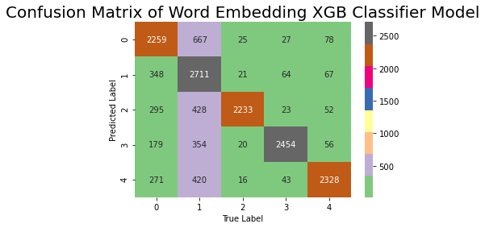

```
{0: 'DC Extended Universe', 1: 'Marvel Cinematic Universe', 2: 'MonsterVerse', 3: 'Star Wars', 4: 'Wizarding World'}
------------------------------------------------------------------------------------------------------------------------
('              precision    recall  f1-score   support\n'
 '\n'
 '           0       0.67      0.74      0.71      3056\n'
 '           1       0.59      0.84      0.70      3211\n'
 '           2       0.96      0.74      0.84      3031\n'
 '           3       0.94      0.80      0.86      3063\n'
 '           4       0.90      0.76      0.82      3078\n'
 '\n'
 '    accuracy                           0.78     15439\n'
 '   macro avg       0.81      0.78      0.78     15439\n'
 'weighted avg       0.81      0.78      0.78     15439\n')
Wall time: 1min 16s
```

```python
%%time
we_xgb_model = xgb.XGBClassifier(
        learning_rate=0.1,
        max_depth=7,
        n_estimators=80,
        use_label_encoder=False,
        eval_metric='auc')
we_xgb_model, score_we_xgb = evaluate_model(x_train_emb_seq, y_train_emb, x_test_emb_seq, y_test_emb, classes,
                                         we_xgb_model, "Word Embedding XGB Classifier", "we_xgb_model.pkl", fresh_load=True)
```

```python
%%time
val_acc_scr_we_xgb, df_rottentomatoes_reviews = validate_wrd_emb_model(wrd_emb_knn_model, "Word Embedding XGB Classifier", "we_xgb",
                                                                df_rottentomatoes_reviews, x_valid_emb_seq)
```

```
Validation Accuracy Score of Word Embedding XGB Classifier Model created using lemmatized word embedding vector is:
 0.2
Wall time: 32.8 s
```

```python
df_rottentomatoes_reviews.to_csv(output_file_name, index = False)
df_rottentomatoes_reviews
```

|  | review | movie_name | label_name | predicted_label_MNB | y_true | y_pred_MNB | predicted_label_knn | y_pred_knn | predicted_label_svc | y_pred_svc | predicted_label_tfidf_rfc | y_pred_tfidf_rfc | predicted_label_we_svc | y_pred_we_svc | predicted_label_we_knn | y_pred_we_knn | predicted_label_we_rfc | y_pred_we_rfc | predicted_label_we_xgb | y_pred_we_xgb |
| --- | --- | --- | --- | --- | --- | --- | --- | --- | --- | --- | --- | --- | --- | --- | --- | --- | --- | --- | --- | --- |
| 0 | 2019's Godzilla: King of the Monsters, does pr... | godzilla_king_of_the_monsters_2019 | MonsterVerse | MonsterVerse | 2 | 2 | MonsterVerse | 2 | MonsterVerse | 2 | MonsterVerse | 2 | Marvel Cinematic Universe | 1 | Star Wars | 3 | Star Wars | 3 | Star Wars | 3 |
| 1 | Shazam!, it's wonderful. It's a very well-dire... | shazam | DC Extended Universe | DC Extended Universe | 0 | 0 | DC Extended Universe | 0 | DC Extended Universe | 0 | DC Extended Universe | 0 | Star Wars | 3 | DC Extended Universe | 0 | DC Extended Universe | 0 | DC Extended Universe | 0 |
| 2 | The crimes of Grindelwald is a very good film ... | fantastic_beasts_the_crimes_of_grindelwald | Wizarding World | Wizarding World | 4 | 4 | Marvel Cinematic Universe | 1 | DC Extended Universe | 0 | MonsterVerse | 2 | Star Wars | 3 | MonsterVerse | 2 | MonsterVerse | 2 | MonsterVerse | 2 |
| 3 | An entertaining film with a great villain and ... | spider_man_homecoming | Marvel Cinematic Universe | Marvel Cinematic Universe | 1 | 1 | MonsterVerse | 2 | Marvel Cinematic Universe | 1 | DC Extended Universe | 0 | Star Wars | 3 | Wizarding World | 4 | Wizarding World | 4 | Wizarding World | 4 |
| 4 | Captain America: Civil War goes a darker direc... | captain_america_civil_war | Marvel Cinematic Universe | Marvel Cinematic Universe | 1 | 1 | Marvel Cinematic Universe | 1 | Marvel Cinematic Universe | 1 | Marvel Cinematic Universe | 1 | Star Wars | 3 | Wizarding World | 4 | Wizarding World | 4 | Wizarding World | 4 |
| ... | ... | ... | ... | ... | ... | ... | ... | ... | ... | ... | ... | ... | ... | ... | ... | ... | ... | ... | ... | ... |
| 260 | Shazam is fun and entertaining! It succeeds in... | shazam | DC Extended Universe | DC Extended Universe | 0 | 0 | DC Extended Universe | 0 | DC Extended Universe | 0 | DC Extended Universe | 0 | Marvel Cinematic Universe | 1 | DC Extended Universe | 0 | DC Extended Universe | 0 | DC Extended Universe | 0 |
| 261 | Godzilla: King of the Monsters was the first M... | godzilla_king_of_the_monsters_2019 | MonsterVerse | MonsterVerse | 2 | 2 | MonsterVerse | 2 | MonsterVerse | 2 | MonsterVerse | 2 | Marvel Cinematic Universe | 1 | Marvel Cinematic Universe | 1 | Marvel Cinematic Universe | 1 | Marvel Cinematic Universe | 1 |
| 262 | Not quite top tier MCU, but very close. This i... | avengers_infinity_war | Marvel Cinematic Universe | Marvel Cinematic Universe | 1 | 1 | Marvel Cinematic Universe | 1 | Marvel Cinematic Universe | 1 | DC Extended Universe | 0 | DC Extended Universe | 0 | Star Wars | 3 | Star Wars | 3 | Star Wars | 3 |
| 263 | There are a lot of mixed feeling about this mo... | thor_the_dark_world | Marvel Cinematic Universe | Marvel Cinematic Universe | 1 | 1 | DC Extended Universe | 0 | Marvel Cinematic Universe | 1 | Marvel Cinematic Universe | 1 | Star Wars | 3 | MonsterVerse | 2 | MonsterVerse | 2 | MonsterVerse | 2 |
| 264 | Skull Island is more Donkey Kong than King Kon... | kong_skull_island | MonsterVerse | MonsterVerse | 2 | 2 | Marvel Cinematic Universe | 1 | MonsterVerse | 2 | Marvel Cinematic Universe | 1 | Marvel Cinematic Universe | 1 | Marvel Cinematic Universe | 1 | Marvel Cinematic Universe | 1 | Marvel Cinematic Universe | 1 |

265 rows × 20 columns

```python
score_we_mnb.append(val_acc_scr_we_mnb)
score_we_svc.append(val_acc_scr_we_svc)
score_we_knn.append(val_acc_scr_we_knn)
score_we_rfc.append(val_acc_scr_we_rfc)
score_we_xgb.append(val_acc_scr_we_xgb)
score_we = score_we_mnb
score_we.extend(score_we_svc)
score_we.extend(score_we_knn)
score_we.extend(score_we_rfc)
score_we.extend(score_we_xgb)
score_we = [score_we]
```

```python
df_score_we = pd.DataFrame(score_we)
df_score_we.columns = pd.MultiIndex.from_product([['MNB Accuracy', 'SVC Accuracy', 'KNN Accuracy', 'RFC Accuracy', 'XGB Accuracy'], ['Train','Test','Validate']])
df_score_we = df_score_we.set_index([['Word Embedding']])
df_score_we[df_score_we.columns] = df_score_we[df_score.columns].applymap("{0:.2f}%".format)
df_score_we
```

|  | MNB Accuracy Train | MNB Accuracy Test | MNB Accuracy Validate | SVC Accuracy Train | SVC Accuracy Test | SVC Accuracy Validate | KNN Accuracy Train | KNN Accuracy Test | KNN Accuracy Validate | RFC Accuracy Train | RFC Accuracy Test | RFC Accuracy Validate | XGB Accuracy Train | XGB Accuracy Test | XGB Accuracy Validate |
| --- | --- | --- | --- | --- | --- | --- | --- | --- | --- | --- | --- | --- | --- | --- | --- |
| Word Embedding | 0.21% | 0.21% | 0.27% | 0.31% | 0.24% | 0.26% | 0.51% | 0.29% | 0.20% | 1.00% | 0.71% | 0.20% | 0.83% | 0.78% | 0.20% |

```python
final_accuracy_df = pd.concat([df_score, df_score_we])
final_accuracy_df
```

|  | MNB Accuracy Train | MNB Accuracy Test | MNB Accuracy Validate | SVC Accuracy Train | SVC Accuracy Test | SVC Accuracy Validate | KNN Accuracy Train | KNN Accuracy Test | KNN Accuracy Validate | RFC Accuracy Train | RFC Accuracy Test | RFC Accuracy Validate | XGB Accuracy Train | XGB Accuracy Test | XGB Accuracy Validate |
| --- | --- | --- | --- | --- | --- | --- | --- | --- | --- | --- | --- | --- | --- | --- | --- |
| Basic Vectorisation | 0.97% | 0.94% | 0.78% | 0.99% | 0.95% | 0.69% | 0.61% | 0.42% | 0.52% | 0.99% | 0.95% | 0.60% | 0.95% | 0.94% | 0.73% |
| Word Embedding | 0.21% | 0.21% | 0.27% | 0.31% | 0.24% | 0.26% | 0.51% | 0.29% | 0.20% | 1.00% | 0.71% | 0.20% | 0.83% | 0.78% | 0.20% |

```python
final_accuracy_df.to_csv("output/final_accuracy.csv")
```